# In-source fragment spectra

Goncalo Graca

2025-09-05

## Obtain the in-source fragment spectrum of a feature of interest

This document summarises an approach to obtaining the in-source fragment (isf) spectrum for a feature of interest. The code uses MSnbase functionality, which increases the speed of the process compared with approaches using xcms for peak-picking (e.g. MetaboAnnotatoR and ‘correlate’ script from Matt Lewis). It also adds spectra comparison capability.

The data used for illustrative purposes was published with the MetaboAnnotatoR paper, and is a truncated Lipid Positive dataset from the MESA Phase 2 cohort (AIF data). After loading the necessary packages, download the data file ‘Lipid_Positive_QC.mzML’ from [this location](https://github.com/gggraca/MetaboAnnotatoR/tree/master/inst/Data/) into the working directory.

```r
library(MSnbase)
library(ggplot2)
rawData <- readMSData("Lipid_Positive_QC.mzML", mode='onDisk', centroided. = TRUE)
```

Filter MS1 spectra. This is important particularly when the data has more than one type of scans, which is the case.

```r
msFilteredData <- filterMsLevel(rawData, msLevel = 1)
```

Read the retention times of the filtered MS1 scans.

```r
RTs <- rtime(msFilteredData)
```

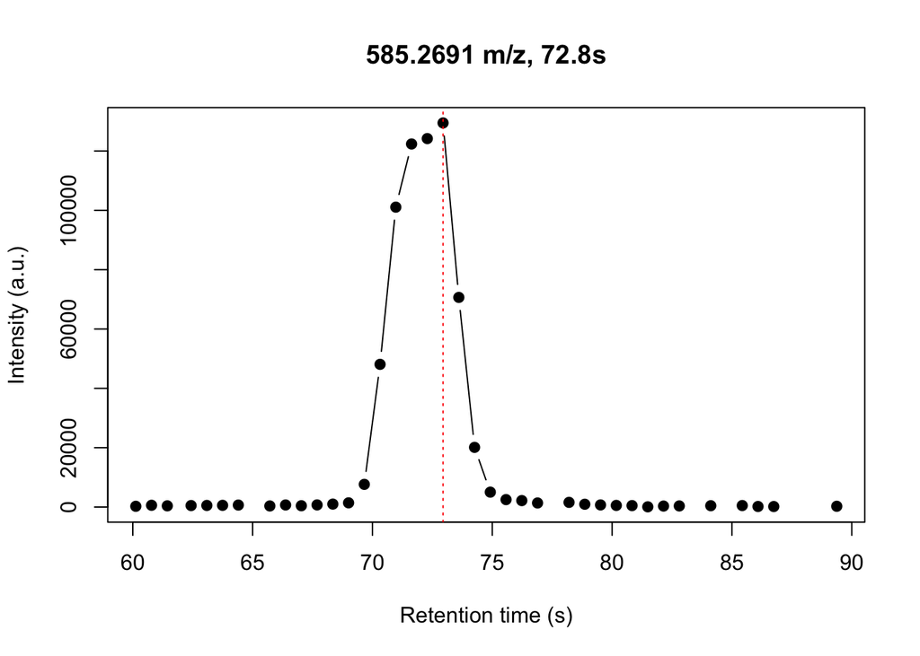

```r
scans <- which(RTs >= 60 & RTs <= 90) # scans corresponding to the feature of interest

rtFilteredData <- msFilteredData[scans] # only scans at the RTs of interest

spectraData <- spectra(rtFilteredData) # spectra for corresponding to the scans of interest

feic <- filterMz(rtFilteredData, mz = c(585.2591, 585.2791)) # EIC object

fint <- as.numeric(intensity(feic)) # intensity for the EIC

frt <- rtime(feic)

apex <- which.max(fint) # apex for the EIC

plot(frt, fint, type = "b", pch = 19, xlab = "Retention time (s)", ylab = "Intensity (a.u.)", main = "585.2691 m/z, 72.8s")
abline(v = frt[apex], col = "red", lty = 3)
```

Gather the m/z and intensity values for the spectrum corresponding to the apex of the EIC of the feature of interest. The most intense features can be used, for instance above 10000 of intensity.

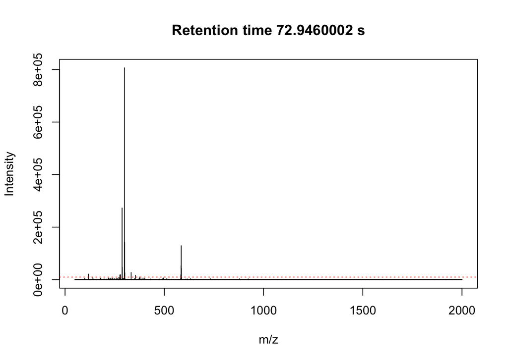

```r
apexSpec <- data.frame(mz = mz(spectraData[[apex]]), intensity = intensity(spectraData[[apex]])) # spectrum to get ISFs from
idx <- which(apexSpec$intensity > 10000)
mzSelected <- apexSpec$mz[idx]
# plot spectrum with RT threshold
plot(apexSpec[,1],apexSpec[,2], type = "h", xlab = "m/z", ylab = "Intensity", main = paste("Retention time", frt[apex], "s"))
abline(h = 10000, col = "red", lty = 3)
```

Generate the EICs for the selected peaks.

```r
# function to get all EICs for the selected peaks from the apex spectrum
# mz tolerance set to 0.01
getEIC <- function(mz, rtFilteredData, tol = 0.01){
  eic <- filterMz(rtFilteredData, mz = c(mz-tol, mz+tol))
  rt <- as.numeric(rtime(eic))
  int <- intensity(eic)
  tmp <- lapply(int, function(x) which(length(x) > 1 | length(x) == 0)) # some features contain 2 intensity values?
  idx <- which(tmp == 1) # map features with two intensity values
  idx <- as.numeric(idx)
  int[idx] <- NA # replace features with two intensity values by NA
  int <- unlist(int)
  df <- data.frame(rt =rt, intensity = int)
  return(df)
}

r <- lapply(mzSelected, function(x) getEIC(x, rtFilteredData, tol = 0.01))
```

Plot the overlap between EICs

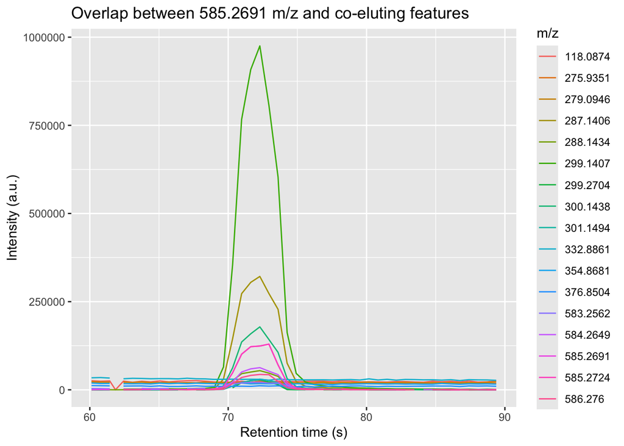

```r
for(i in 1:length(mzSelected)){
  r[[i]][,"mz"] <- round(mzSelected[i], 4)
}
df <- do.call(rbind,r)
df <- rbind(data.frame(rt = frt, intensity = fint, mz = 585.2691),df)
ggplot(df, aes(rt, intensity, col = factor(mz))) + geom_line() +
  labs(title = "Overlap between 585.2691 m/z and co-eluting features", x = "Retention time (s)", y = "Intensity (a.u.)", col = "m/z")
```

Obtain the in-source fragment pseudo-spectrum from the EICs of the features that best correlate with the EIC of the feature of interest (C > 0.95):

```r
# correlate the feature EIC with the other features EICs
c <- lapply(r, function(x) cor(fint, x[,2], use = "pairwise.complete.obs"))
c <- unlist(c)

# select features with the highest correlation coefficient
isf <- mzSelected[which(c > 0.95)]

# obtain the pseudo-in source fragment (ISF) spectrum
idx <- sapply(isf, function(x) grep(x, apexSpec$mz))
isfSpec <- apexSpec[idx,]
```

Compare the in-source fragment pseudo-spectrum with the apex spectrum:

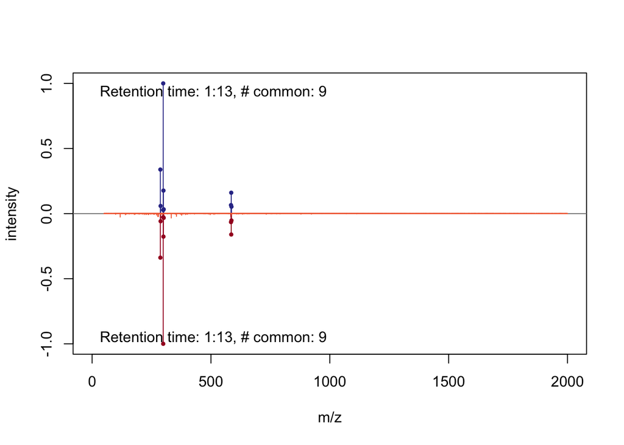

```r
# convert the feature and the ISF spectra into "Spectrum1" class objects to use spectra comparison functionality from the MSnbase package
isfSpec <- new("Spectrum1", mz = isfSpec$mz, intensity = isfSpec$intensity, centroided = TRUE, rt = as.numeric(frt[apex]))
apexSpec <- new("Spectrum1", mz = apexSpec$mz, intensity = apexSpec$intensity, centroided = TRUE, rt = as.numeric(frt[apex]))
# mirror plot
plot(isfSpec, apexSpec)
```

```r
# spectra comparison metrics
dp <- compareSpectra(isfSpec,apexSpec, fun = "dotproduct") # dotproduct comparison
pc <- compareSpectra(isfSpec,apexSpec, fun = "cor") # Pearson correlation
ci <- compareSpectra(isfSpec,apexSpec, fun = "common") # common peaks between the two spectra
print(paste("Spectra comparison metrics:", "Dot product:", round(dp,4), ",",
            "Pearson correlation:", round(pc,4), ",",
            "Common ions:", ci))
```

```
## [1] "Spectra comparison metrics: Dot product: 0.996 , Pearson correlation: 0.997 , Common ions: 9"
```